# Introduction to Data Visualization

### Data Visualization

Data Visualization is an important part of Data Science. It is the presentation of data in a pictorial or graphical format, an effective way to communicate your findings about the dataset. The goals of visualization are:

- To gain powerful insights into data that aren't obvious with statistics.
- Business and non-technical audience are able to comprehend the results.
- Useful to build stories so peer data scientists can understand the analysis.

### 1. Matplotlib

Matplotlib is a basic graphing library in python. It is the most commonly used package by data scientists for visualization. Many of the more advanced visualization tools use matplotlib as the base library. Hence you will need to develop some basic familiarity with how to use matplotlib.

Let us learn to use matplotlib by plotting the sine curve. The sine of a variable can be computed using the numpy library with np.sin() function.

```
import matplotlib.pyplot as plt
import numpy as np

x = np.linspace(-np.pi, np.pi, 100)
plt.plot(x, np.sin(x))
plt.xlabel('Theta')
plt.ylabel('y=sin(x)')
plt.show()
```

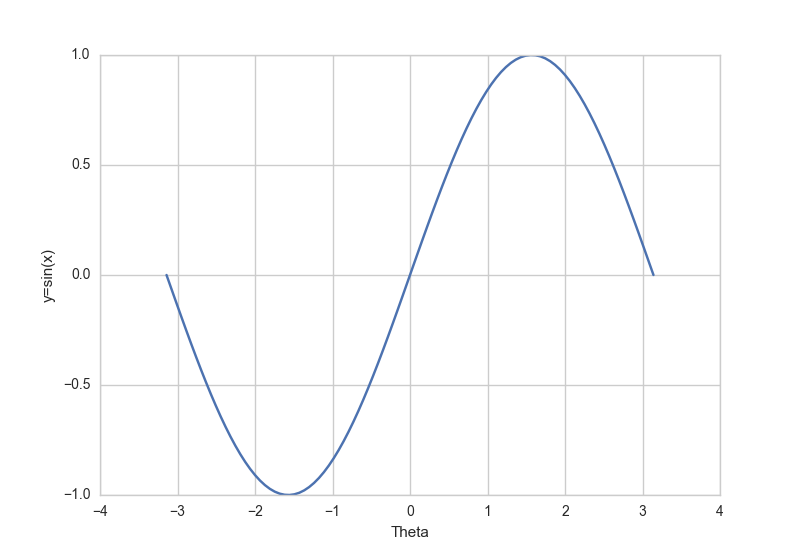

### 1.1 *Scatter Plot*

A scatter plot shows the relationship between two numerical variables. Each member of the dataset gets plotted as a point whose (x, y) coordinates relates to its values for the two variables.

Let's walk through a very simple example using two numpy arrays.

```python
import numpy as np
import matplotlib.pyplot as plt

x = np.linspace(0, 5, 11)
y = x ** 2

plt.scatter(x, y)
plt.xlabel('X values')
plt.ylabel('X values')
plt.title('Scatter Plot')
plt.show()
```

[output not shown]

## Exercise:

For the 'iris' dataset generate a scatter plot using matplotlib to visualize the relationship between 'petal length (cm)' and 'petal width (cm)'. Use plt.show()

```python
import pandas as pd
from sklearn import datasets
raw_data = datasets.load_iris()
iris = pd.DataFrame(raw_data.data, columns= raw_data.feature_names)
iris.head()
```

|  | sepal length (cm) | sepal width (cm) | petal length (cm) | petal width (cm) |
| --- | --- | --- | --- | --- |
| 0 | 5.1 | 3.5 | 1.4 | 0.2 |
| 1 | 4.9 | 3.0 | 1.4 | 0.2 |
| 2 | 4.7 | 3.2 | 1.3 | 0.2 |
| 3 | 4.6 | 3.1 | 1.5 | 0.2 |
| 4 | 5.0 | 3.6 | 1.4 | 0.2 |

### Solution

```
plt.scatter(iris['petal length (cm)'],iris['petal width (cm)'])
plt.show()
```

### 1.2 *Distribution Plot*

A distribution plot is suitable for comparing range and distribution of numerical data. Distribution of continuous variables is called continuous distribution and distribution of discrete variables is called discrete distribution. In matplotlib distributions are called histograms and visualized using hist() plot.

Let's see the continuous distribution of values in a randomly generated array.

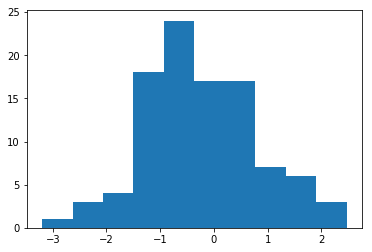

```python
x = np.random.normal(size=100)
plt.hist(x)
plt.show()
```

## Exercise:

For the 'iris' dataset generate a distribution plot using matplotlib to visualize the distribution of 'sepal_length'. Use plt.show()

```python
#Write your solution below
```

### Solution

```
plt.hist(iris['sepal length (cm)'])
plt.show()
```

### 2. Seaborn

Seaborn is a Python visualization library based on matplotlib. It provides a high-level interface for drawing attractive statistical graphics. The graphs produced are also aesthetic and convey more information useful for Data Scientists.

Seaborn comes with built-in data sets! Let's see how we can import tips dataset and analyze it using seaborn.

```python
import seaborn as sns

tips = sns.load_dataset('tips')
tips.head()
```

|  | total_bill | tip | sex | smoker | day | time | size |
| --- | --- | --- | --- | --- | --- | --- | --- |
| 0 | 16.99 | 1.01 | Female | No | Sun | Dinner | 2 |
| 1 | 10.34 | 1.66 | Male | No | Sun | Dinner | 3 |
| 2 | 21.01 | 3.50 | Male | No | Sun | Dinner | 3 |
| 3 | 23.68 | 3.31 | Male | No | Sun | Dinner | 2 |
| 4 | 24.59 | 3.61 | Female | No | Sun | Dinner | 4 |

### 2.1 *Joint Plot*

Seaborn's joint plot also shows the relationship between two numerical variables. It is equivalent to matplotlib's scatterplot.

Let's see how people 'tip' w.r.t the 'total_bill' in the tips dataset.

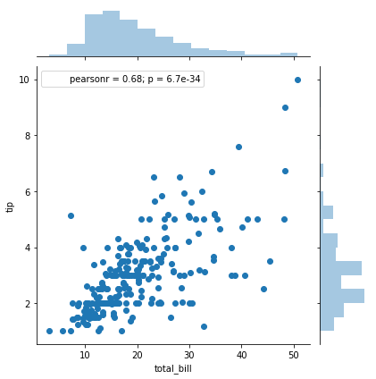

```python
sns.jointplot(x='total_bill',y='tip',data=tips)
plt.show()
```

## Exercise:

Import seaborn's inbuilt dataset titanic into variable named 'titanic' and show the relationship between 'age' and 'fare' of people using a jointplot.

```python
# write your code below
```

### Solution

```
titanic = sns.load_dataset('titanic')

sns.jointplot(x='age',y='fare',data=titanic)
plt.show()
```

### 2.2 *Distribution Plot*

Seaborn has a number of plots to visualize distributions. The most important one is the dist plot which shows distribution of a univariate set of observations. Other distribution plots are rugplot and kdeplot.

Let's see the distribution of 'total_bill in the tips dataset.

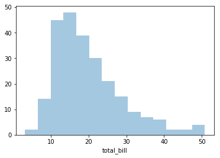

```python
sns.distplot(tips['total_bill'], kde=False)
plt.show()
```

## Exercise:

For the 'tips' dataset generate a distribution plot using seaborn to visualize the distribution of 'tip' paid. Use plt.show()

```python
#write your code below
```

### Solution

```
sns.distplot(tips['tip'], kde=False)
plt.show()
```